# Project: Investigate a Dataset (Medical Appointment No Shows)

- Introduction
- Data Wrangling
- Exploratory Data Analysis
- Conclusions

## Introduction

**Data Set**: No-show appointments dataset collects information from 100k medical appointments in Brazil and is focused on the question of whether or not patients show up for their appointment

**PatientId**: indicates the patient ID; duplication is possible due to cases where the same patient booked more than one appointment.

**AppointmentID**: indicates appoint ID, this field should be unique

**Gender**: indicates the patient's gender (M/F)

**ScheduledDay**: tells us on what day the patient set up their appointment.

**Neighborhood**: indicates the location of the hospital.

**Scholarship**: indicates whether or not the patient is enrolled in Brasilian welfare program.

**Hipertension**: indicates whether or not the patient is experiencing Hypertension.

**Diabetes**: indicates whether or not the patient is experiencing Diabetes.

**Alcoholism**: indicates whether or not the patient is experiencing Alcoholism.

**Handcap**: indicates whether or not the patient is with special needs.

**SMS_received**: indicates whether or not the patient has received a reminder text message.

**Show-up**: ‘No’ if the patient showed up to their appointment, and ‘Yes’ if they did not show up

#### The questions that I want to answer are :

1. What is the influence of the days between the scheduled date and the appointed date on the no-show percentage?
2. What is the influence of Age on the no-show percentage?
3. What is the influence of the day of the week on the no-show percentage?

```python
# Use this cell to set up import statements for all of the packages that you
#   plan to use.
import matplotlib.pyplot as plt
import numpy as np
import pandas as pd
import seaborn as sns

%matplotlib inline
%config InlineBackend.figure_format = 'retina'


# Remember to include a 'magic word' so that your visualizations are plotted
#   inline with the notebook. See this page for more:
#   http://ipython.readthedocs.io/en/stable/interactive/magics.html
```

## Data Wrangling

> **Tip**: In this section of the report, you will load in the data, check for cleanliness, and then trim and clean your dataset for analysis. Make sure that you document your steps carefully and justify your cleaning decisions.

### General Properties

```python
# Load the data
df = pd.read_csv('https://d17h27t6h515a5.cloudfront.net/topher/2017/October/59dd2e9a_noshowappointments-kagglev2-may-2016/noshowappointments-kagglev2-may-2016.csv')
#  types and look for instances of missing or possibly errant data.
#print out a few lines to see the data
```

```python
df.head()
```

|  | PatientId | AppointmentID | Gender | ScheduledDay | AppointmentDay | Age | Neighbourhood | Scholarship | Hipertension | Diabetes | Alcoholism | Handcap | SMS_received | No-show |
| --- | --- | --- | --- | --- | --- | --- | --- | --- | --- | --- | --- | --- | --- | --- |
| 0 | 2.987250e+13 | 5642903 | F | 2016-04-29T18:38:08Z | 2016-04-29T00:00:00Z | 62 | JARDIM DA PENHA | 0 | 1 | 0 | 0 | 0 | 0 | No |
| 1 | 5.589978e+14 | 5642503 | M | 2016-04-29T16:08:27Z | 2016-04-29T00:00:00Z | 56 | JARDIM DA PENHA | 0 | 0 | 0 | 0 | 0 | 0 | No |
| 2 | 4.262962e+12 | 5642549 | F | 2016-04-29T16:19:04Z | 2016-04-29T00:00:00Z | 62 | MATA DA PRAIA | 0 | 0 | 0 | 0 | 0 | 0 | No |
| 3 | 8.679512e+11 | 5642828 | F | 2016-04-29T17:29:31Z | 2016-04-29T00:00:00Z | 8 | PONTAL DE CAMBURI | 0 | 0 | 0 | 0 | 0 | 0 | No |
| 4 | 8.841186e+12 | 5642494 | F | 2016-04-29T16:07:23Z | 2016-04-29T00:00:00Z | 56 | JARDIM DA PENHA | 0 | 1 | 1 | 0 | 0 | 0 | No |

```python
df.describe()
```

|  | PatientId | AppointmentID | Age | Scholarship | Hipertension | Diabetes | Alcoholism | Handcap | SMS_received |
| --- | --- | --- | --- | --- | --- | --- | --- | --- | --- |
| count | 1.105270e+05 | 1.105270e+05 | 110527.000000 | 110527.000000 | 110527.000000 | 110527.000000 | 110527.000000 | 110527.000000 | 110527.000000 |
| mean | 1.474963e+14 | 5.675305e+06 | 37.088874 | 0.098266 | 0.197246 | 0.071865 | 0.030400 | 0.022248 | 0.321026 |
| std | 2.560949e+14 | 7.129575e+04 | 23.110205 | 0.297675 | 0.397921 | 0.258265 | 0.171686 | 0.161543 | 0.466873 |
| min | 3.921784e+04 | 5.030230e+06 | -1.000000 | 0.000000 | 0.000000 | 0.000000 | 0.000000 | 0.000000 | 0.000000 |
| 25% | 4.172614e+12 | 5.640286e+06 | 18.000000 | 0.000000 | 0.000000 | 0.000000 | 0.000000 | 0.000000 | 0.000000 |
| 50% | 3.173184e+13 | 5.680573e+06 | 37.000000 | 0.000000 | 0.000000 | 0.000000 | 0.000000 | 0.000000 | 0.000000 |
| 75% | 9.439172e+13 | 5.725524e+06 | 55.000000 | 0.000000 | 0.000000 | 0.000000 | 0.000000 | 0.000000 | 1.000000 |
| max | 9.999816e+14 | 5.790484e+06 | 115.000000 | 1.000000 | 1.000000 | 1.000000 | 1.000000 | 4.000000 | 1.000000 |

```python
#checking for null values
df.isnull().sum()

#there is no missing value in the data
```

```
PatientId         0
AppointmentID     0
Gender            0
ScheduledDay      0
AppointmentDay    0
Age               0
Neighbourhood     0
Scholarship       0
Hipertension      0
Diabetes          0
Alcoholism        0
Handcap           0
SMS_received      0
No-show           0
dtype: int64
```

```python
#checking for the duplicate values
df.duplicated().sum()
```

```
0
```

```python
# this displays the summary of the dataframe,
# including the number of non-null values in each column
df.info()
```

[output not shown]

```python
#checking for the data type to see if all columns in appropriate type
df.dtypes
```

[output not shown]

```python
df.shape
```

[output not shown]

```python
# this returns the number of unique values in each column
df.nunique()
```

[output not shown]

```python
#this return all the columns name in the dataset
df.columns
```

[output not shown]

```python
#discovring the unique value in 'age' column
df.Age.unique()
```

[output not shown]

There is nonsensical value such as -1

```python
#convert yes and no to 1 and 0 and assign it to a new column to make it more easy to analyse
df['conv_No-show'] = df['No-show'].map({'Yes':1, 'No':0})
```

```python
#discovering the correlations between columns
corr = df.corr()
corr
```

|  | PatientId | AppointmentID | Age | Scholarship | Hipertension | Diabetes | Alcoholism | Handcap | SMS_received | conv_No-show |
| --- | --- | --- | --- | --- | --- | --- | --- | --- | --- | --- |
| PatientId | 1.000000 | 0.004039 | -0.004139 | -0.002880 | -0.006441 | 0.001605 | 0.011011 | -0.007916 | -0.009749 | -0.001461 |
| AppointmentID | 0.004039 | 1.000000 | -0.019126 | 0.022615 | 0.012752 | 0.022628 | 0.032944 | 0.014106 | -0.256618 | -0.162602 |
| Age | -0.004139 | -0.019126 | 1.000000 | -0.092457 | 0.504586 | 0.292391 | 0.095811 | 0.078033 | 0.012643 | -0.060319 |
| Scholarship | -0.002880 | 0.022615 | -0.092457 | 1.000000 | -0.019729 | -0.024894 | 0.035022 | -0.008586 | 0.001194 | 0.029135 |
| Hipertension | -0.006441 | 0.012752 | 0.504586 | -0.019729 | 1.000000 | 0.433086 | 0.087971 | 0.080083 | -0.006267 | -0.035701 |
| Diabetes | 0.001605 | 0.022628 | 0.292391 | -0.024894 | 0.433086 | 1.000000 | 0.018474 | 0.057530 | -0.014550 | -0.015180 |
| Alcoholism | 0.011011 | 0.032944 | 0.095811 | 0.035022 | 0.087971 | 0.018474 | 1.000000 | 0.004648 | -0.026147 | -0.000196 |
| Handcap | -0.007916 | 0.014106 | 0.078033 | -0.008586 | 0.080083 | 0.057530 | 0.004648 | 1.000000 | -0.024161 | -0.006076 |
| SMS_received | -0.009749 | -0.256618 | 0.012643 | 0.001194 | -0.006267 | -0.014550 | -0.026147 | -0.024161 | 1.000000 | 0.126431 |
| conv_No-show | -0.001461 | -0.162602 | -0.060319 | 0.029135 | -0.035701 | -0.015180 | -0.000196 | -0.006076 | 0.126431 | 1.000000 |

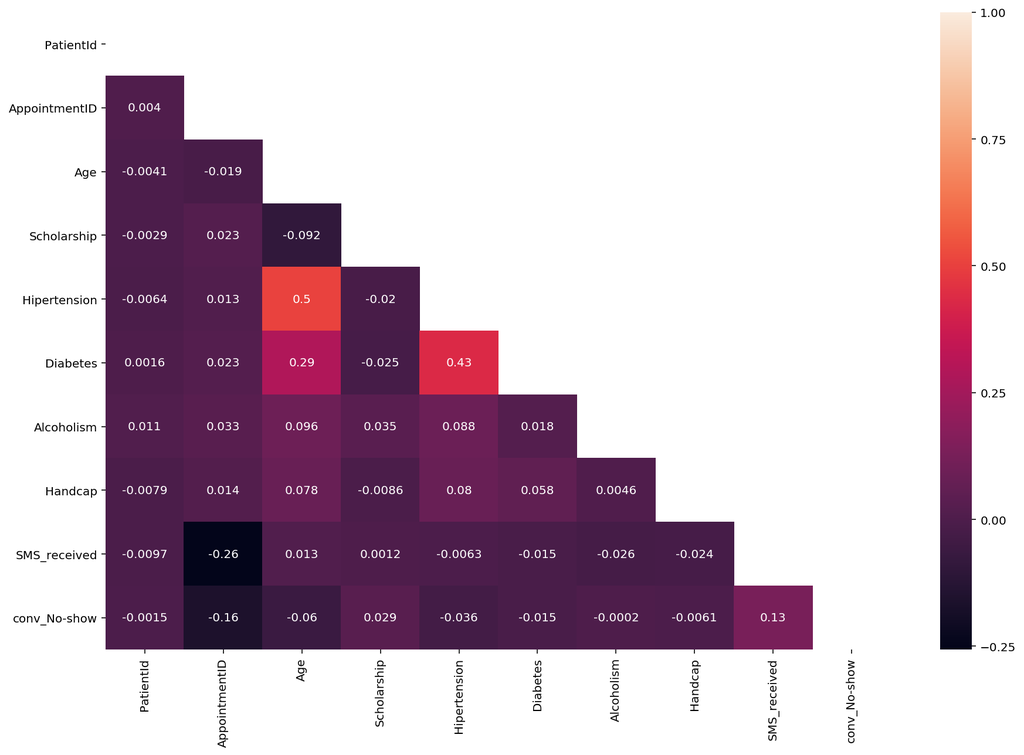

```python
#Plotting the correlation to make the correlation easy to recognize
fig, ax = plt.subplots(figsize=(15,10))

mask = np.zeros_like(corr, dtype=np.bool)
mask[np.triu_indices_from(mask)] = True

ax = sns.heatmap(corr, mask=mask, ax=ax, annot=True)

ax.set_xticklabels(ax.xaxis.get_ticklabels(), fontsize=10)
ax.set_yticklabels(ax.yaxis.get_ticklabels(), fontsize=10)

plt.show()
```

### Data Cleaning

**Drop the nonsensical value In Age Column**

```python
df = df.drop(df.index[df.Age == -1])
df.Age.unique()
```

```
array([ 62,  56,   8,  76,  23,  39,  21,  19,  30,  29,  22,  28,  54,
        15,  50,  40,  46,   4,  13,  65,  45,  51,  32,  12,  61,  38,
        79,  18,  63,  64,  85,  59,  55,  71,  49,  78,  31,  58,  27,
         6,   2,  11,   7,   0,   3,   1,  69,  68,  60,  67,  36,  10,
        35,  20,  26,  34,  33,  16,  42,   5,  47,  17,  41,  44,  37,
        24,  66,  77,  81,  70,  53,  75,  73,  52,  74,  43,  89,  57,
        14,   9,  48,  83,  72,  25,  80,  87,  88,  84,  82,  90,  94,
        86,  91,  98,  92,  96,  93,  95,  97, 102, 115, 100,  99])
```

**Remove typos**

```python
df.rename(columns={'Handcap':'Handicap',
                   'Hipertension':'Hypertension'},
          inplace=True
         )
df.head(3)
```

|  | PatientId | AppointmentID | Gender | ScheduledDay | AppointmentDay | Age | Neighbourhood | Scholarship | Hypertension | Diabetes | Alcoholism | Handicap | SMS_received | No-show | conv_No-show |
| --- | --- | --- | --- | --- | --- | --- | --- | --- | --- | --- | --- | --- | --- | --- | --- |
| 0 | 2.987250e+13 | 5642903 | F | 2016-04-29T18:38:08Z | 2016-04-29T00:00:00Z | 62 | JARDIM DA PENHA | 0 | 1 | 0 | 0 | 0 | 0 | No | 0 |
| 1 | 5.589978e+14 | 5642503 | M | 2016-04-29T16:08:27Z | 2016-04-29T00:00:00Z | 56 | JARDIM DA PENHA | 0 | 0 | 0 | 0 | 0 | 0 | No | 0 |
| 2 | 4.262962e+12 | 5642549 | F | 2016-04-29T16:19:04Z | 2016-04-29T00:00:00Z | 62 | MATA DA PRAIA | 0 | 0 | 0 | 0 | 0 | 0 | No | 0 |

```python
# convert the 'AppointmentDay' column to a datetime object
df['AppointmentDay'] = pd.to_datetime(df['AppointmentDay'], dayfirst=True)

# create a new column for 'Month',and 'Day_of_Week' from AppointmentDay
#that will make them easy to use if we need them in the analysis
df['Appointment_Month'] = df['AppointmentDay'].dt.month
df['Appointment_Day_of_Week'] = df['AppointmentDay'].dt.dayofweek
```

```python
# convert the 'ScheduledDay' column to a datetime object
df['ScheduledDay'] = pd.to_datetime(df['ScheduledDay'], dayfirst=True)

# create a new column for 'Month',and 'Day_of_Week' from AppointmentDay
#that will make them easy to use if we need them in the analysis
df['Scheduled_Month'] = df['ScheduledDay'].dt.month
df['Scheduled_Day_of_Week'] = df['ScheduledDay'].dt.dayofweek
#check the first couple rows to make sure it's what I want
df.head(2)
```

|  | PatientId | AppointmentID | Gender | ScheduledDay | AppointmentDay | Age | Neighbourhood | Scholarship | Hypertension | Diabetes | Alcoholism | Handicap | SMS_received | No-show | conv_No-show | Appointment_Month | Appointment_Day_of_Week | Scheduled_Month | Scheduled_Day_of_Week |
| --- | --- | --- | --- | --- | --- | --- | --- | --- | --- | --- | --- | --- | --- | --- | --- | --- | --- | --- | --- |
| 0 | 2.987250e+13 | 5642903 | F | 2016-04-29 18:38:08 | 2016-04-29 | 62 | JARDIM DA PENHA | 0 | 1 | 0 | 0 | 0 | 0 | No | 0 | 4 | 4 | 4 | 4 |
| 1 | 5.589978e+14 | 5642503 | M | 2016-04-29 16:08:27 | 2016-04-29 | 56 | JARDIM DA PENHA | 0 | 0 | 0 | 0 | 0 | 0 | No | 0 | 4 | 4 | 4 | 4 |

```python
#re-assign the 'ScheduledDay' column to a new varible 'ScheduledDate' and conver it to date to remove the time since we do not need it
df['ScheduledDate'] = df['ScheduledDay'].dt.date

#converting 'ScheduledDate' to datetime to be as same type as 'AppointmentDay'
df['ScheduledDate'] = pd.to_datetime(df['ScheduledDate'], dayfirst=True)
df.head(2)
```

|  | PatientId | AppointmentID | Gender | ScheduledDay | AppointmentDay | Age | Neighbourhood | Scholarship | Hypertension | Diabetes | Alcoholism | Handicap | SMS_received | No-show | conv_No-show | Appointment_Month | Appointment_Day_of_Week | Scheduled_Month | Scheduled_Day_of_Week | ScheduledDate |
| --- | --- | --- | --- | --- | --- | --- | --- | --- | --- | --- | --- | --- | --- | --- | --- | --- | --- | --- | --- | --- |
| 0 | 2.987250e+13 | 5642903 | F | 2016-04-29 18:38:08 | 2016-04-29 | 62 | JARDIM DA PENHA | 0 | 1 | 0 | 0 | 0 | 0 | No | 0 | 4 | 4 | 4 | 4 | 2016-04-29 |
| 1 | 5.589978e+14 | 5642503 | M | 2016-04-29 16:08:27 | 2016-04-29 | 56 | JARDIM DA PENHA | 0 | 0 | 0 | 0 | 0 | 0 | No | 0 | 4 | 4 | 4 | 4 | 2016-04-29 |

```python
# drop 'ScheduledDay' because we don't need it now after we added the new column 'ScheduledDate'

df.drop(labels='ScheduledDay', axis=1, inplace=True)
```

```python
#Create a new column to show the Waiting Duration (in days) between the scheduling date and appointment date
df['Waiting_Duration'] = df.AppointmentDay - df.ScheduledDate
```

```python
#check if there is no nonsensical values
df[df['Waiting_Duration'] < '0 days']
```

|  | PatientId | AppointmentID | Gender | AppointmentDay | Age | Neighbourhood | Scholarship | Hypertension | Diabetes | Alcoholism | Handicap | SMS_received | No-show | conv_No-show | Appointment_Month | Appointment_Day_of_Week | Scheduled_Month | Scheduled_Day_of_Week | ScheduledDate | Waiting_Duration |
| --- | --- | --- | --- | --- | --- | --- | --- | --- | --- | --- | --- | --- | --- | --- | --- | --- | --- | --- | --- | --- |
| 27033 | 7.839273e+12 | 5679978 | M | 2016-05-09 | 38 | RESISTÊNCIA | 0 | 0 | 0 | 0 | 1 | 0 | Yes | 1 | 5 | 0 | 5 | 1 | 2016-05-10 | -1 days |
| 55226 | 7.896294e+12 | 5715660 | F | 2016-05-17 | 19 | SANTO ANTÔNIO | 0 | 0 | 0 | 0 | 1 | 0 | Yes | 1 | 5 | 1 | 5 | 2 | 2016-05-18 | -1 days |
| 64175 | 2.425226e+13 | 5664962 | F | 2016-05-04 | 22 | CONSOLAÇÃO | 0 | 0 | 0 | 0 | 0 | 0 | Yes | 1 | 5 | 2 | 5 | 3 | 2016-05-05 | -1 days |
| 71533 | 9.982316e+14 | 5686628 | F | 2016-05-05 | 81 | SANTO ANTÔNIO | 0 | 0 | 0 | 0 | 0 | 0 | Yes | 1 | 5 | 3 | 5 | 2 | 2016-05-11 | -6 days |
| 72362 | 3.787482e+12 | 5655637 | M | 2016-05-03 | 7 | TABUAZEIRO | 0 | 0 | 0 | 0 | 0 | 0 | Yes | 1 | 5 | 1 | 5 | 2 | 2016-05-04 | -1 days |

As we see from the datafram above there are 5 appointments where the appointment has booked after the actual appointment. At the same time the patient did not show up with no reason explained, so I will exclude them from the data.

```python
#exclude the negative durations
df = df[ ~ (df['Waiting_Duration'] < '0')]
df.shape
```

```
(110521, 20)
```

```python
#Rename the Gender values and make them Female & Male to be more readable
df['Gender'] = df.Gender.astype('category')
df.Gender.cat.rename_categories(['Female','Male'], inplace = True)
```

```python
# Convert days of week from number to name to be more readable
df['Appointment_Day_of_Week'] = df.AppointmentDay.map(lambda x : x.strftime('%A'))
```

## Exploratory Data Analysis

> **Tip**: Now that you've trimmed and cleaned your data, you're ready to move on to exploration. Compute statistics and create visualizations with the goal of addressing the research questions that you posed in the Introduction section. It is recommended that you be systematic with your approach. Look at one variable at a time, and then follow it up by looking at relationships between variables.

```
Text(0.5,0,'Age')
```

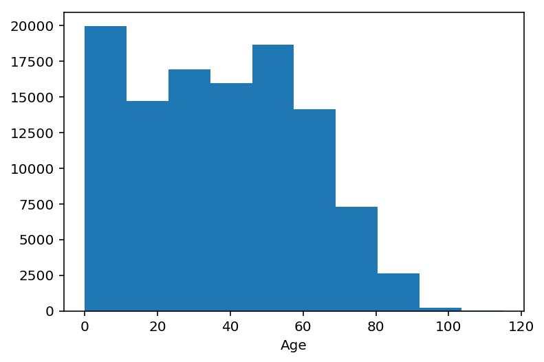

```python
#Ploting Patient 'Age' to see how it distributed
hist = plt.hist(df.Age, bins=None)
# plt.xlabel('categories')
plt.xlabel('Age')
```

Most of patients' age are from 0 to 10 and then approxmitaly from 55 to 60. The number of patients from 80 and more are less than other ages

### Q1: What is the influence of the days between the scheduled date and the appointed date on the no-show percentage?

```python
#grobing by 'Waiting_Duration' and count the number of no show Patient for each 'Waiting_Duration'
df_duration = df[['conv_No-show','Waiting_Duration']].groupby(['Waiting_Duration']).count()
df_duration
```

| Waiting_Duration | conv_No-show |
| --- | --- |
| 0 days | 38562 |
| 1 days | 5213 |
| 2 days | 6725 |
| 3 days | 2737 |
| 4 days | 5290 |
| 5 days | 3277 |
| 6 days | 4037 |
| 7 days | 4906 |
| 8 days | 2332 |
| 9 days | 1605 |
| 10 days | 1391 |
| 11 days | 987 |
| 12 days | 1115 |
| 13 days | 1682 |
| 14 days | 2913 |
| 15 days | 1503 |
| 16 days | 1151 |
| 17 days | 1107 |
| 18 days | 1021 |
| 19 days | 1044 |
| 20 days | 1187 |
| 21 days | 1861 |
| 22 days | 1173 |
| 23 days | 822 |
| 24 days | 622 |
| 25 days | 637 |
| 26 days | 731 |
| 27 days | 1013 |
| 28 days | 1706 |
| 29 days | 1089 |
| ... | ... |
| 101 days | 1 |
| 102 days | 4 |
| 103 days | 5 |
| 104 days | 8 |
| 105 days | 4 |
| 107 days | 2 |
| 108 days | 5 |
| 109 days | 5 |
| 110 days | 2 |
| 111 days | 5 |
| 112 days | 5 |
| 115 days | 2 |
| 117 days | 1 |
| 119 days | 4 |
| 122 days | 3 |
| 123 days | 1 |
| 125 days | 1 |
| 126 days | 1 |
| 127 days | 1 |
| 132 days | 1 |
| 133 days | 11 |
| 139 days | 1 |
| 142 days | 8 |
| 146 days | 1 |
| 151 days | 1 |
| 155 days | 10 |
| 162 days | 11 |
| 169 days | 8 |
| 176 days | 16 |
| 179 days | 10 |

129 rows × 1 columns

Since the number of witting days are more than 100 days I will just take the witting duration until 30 days

```python
# excluding the witting duration that are more than 30 days
df_duration = df[df['Waiting_Duration'] <='30 days']
```

```
Text(0.5,0,'Days between scheduling and appointment')
```

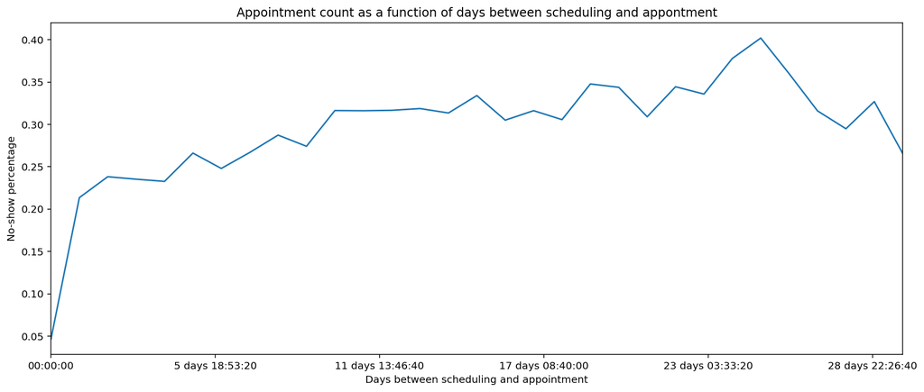

```python
df_duration = df_duration[['conv_No-show','Waiting_Duration']].groupby(['Waiting_Duration']).mean()
plot_title = 'Appointment count as a function of days between scheduling and appontment'
ax = df_duration['conv_No-show'].plot(kind='line', figsize=(15, 6), title=plot_title)
ax.set_ylabel('No-show percentage')
ax.set_xlabel('Days between scheduling and appointment')
```

The line chart shows that the percentage of no show is less if the appointment is scheduled on the day of the appointment then the no show percentage increased rapidly. The beak of the no show percentage which is 40% is approximately at 25 days.

### What is the influence of gender on the no-show percentage?

```python
#Grouping by 'Gender' to count the number of no show patient based on Gender
df_gender = df.groupby('Gender', as_index=False).agg({"No-show": "count"})
df_gender
```

|  | Gender | No-show |
| --- | --- | --- |
| 0 | Female | 71836 |
| 1 | Male | 38685 |

```python
#creating a functioin that will calculate the percentage of no show for each gender
def gender_persent (gender , types):
    total_value = (df[gender]== types).sum()
    NoShow = len((df[(df[gender]== types) & (df['No-show']== 'Yes')]))
    print(int((NoShow/total_value)*100),'%' ,'of ' ,types , 'did not show up in their appointments of', total_value )
```

```python
gender_persent('Gender', 'Female')
gender_persent('Gender','Male')
```

```
20 % of  Female did not show up in their appointments of 71836
19 % of  Male did not show up in their appointments of 38685
```

The percentage of no show betweem male and female has a slight difference which is just 1%, so gender has no influence on the no show for the appointements

### Q2: What is the influence of Age on the no-show percentage?

```python
#Groping Age to make it more easy to analyze
bins = [0,10,20,30,40,50,60,70,80,90,100,110,120]

df['gorup_age'] = pd.cut(df.Age,bins)
df.head(2)
```

|  | PatientId | AppointmentID | Gender | AppointmentDay | Age | Neighbourhood | Scholarship | Hypertension | Diabetes | Alcoholism | ... | SMS_received | No-show | conv_No-show | Appointment_Month | Appointment_Day_of_Week | Scheduled_Month | Scheduled_Day_of_Week | ScheduledDate | Waiting_Duration | gorup_age |
| --- | --- | --- | --- | --- | --- | --- | --- | --- | --- | --- | --- | --- | --- | --- | --- | --- | --- | --- | --- | --- | --- |
| 0 | 2.987250e+13 | 5642903 | Female | 2016-04-29 | 62 | JARDIM DA PENHA | 0 | 1 | 0 | 0 | ... | 0 | No | 0 | 4 | Friday | 4 | 4 | 2016-04-29 | 0 days | (60, 70] |
| 1 | 5.589978e+14 | 5642503 | Male | 2016-04-29 | 56 | JARDIM DA PENHA | 0 | 0 | 0 | 0 | ... | 0 | No | 0 | 4 | Friday | 4 | 4 | 2016-04-29 | 0 days | (50, 60] |

2 rows × 21 columns

```python
#sum the number of no show groped by age
df_age = df.groupby('gorup_age')['conv_No-show'].count()
df_age
```

```
gorup_age
(0, 10]       15209
(10, 20]      13098
(20, 30]      13782
(30, 40]      15051
(40, 50]      14420
(50, 60]      15661
(60, 70]      11189
(70, 80]       5721
(80, 90]       2543
(90, 100]       301
(100, 110]        2
(110, 120]        5
Name: conv_No-show, dtype: int64
```

```
Text(0.5,0,'Patient age (in 10 year bins)')
```

[figure not shown]

```python
df_age = df[['conv_No-show', 'gorup_age']].groupby('gorup_age').count()
plot_title = 'No-show percentage as a function of age'
ax = df_age['conv_No-show'].plot(kind='bar', figsize=(15, 3), title=plot_title)
ax.set_ylabel('No-show percentage')
ax.set_xlabel('Patient age (in 10 year bins)')
```

### Q3: What is the influence of the day of the week on the no-show percentage?

```python
#calulating the mean of no show groping by days of week
df_day_of_week = df[['conv_No-show', 'Appointment_Day_of_Week']].groupby('Appointment_Day_of_Week').mean()
df_day_of_week.head(7)
```

| Appointment_Day_of_Week | conv_No-show |
| --- | --- |
| Friday | 0.212261 |
| Monday | 0.206446 |
| Saturday | 0.230769 |
| Thursday | 0.193494 |
| Tuesday | 0.200874 |
| Wednesday | 0.196861 |

From the data avove we can see that there is no appointment on sunday

```
Text(0.5,0,'Day of the week')
```

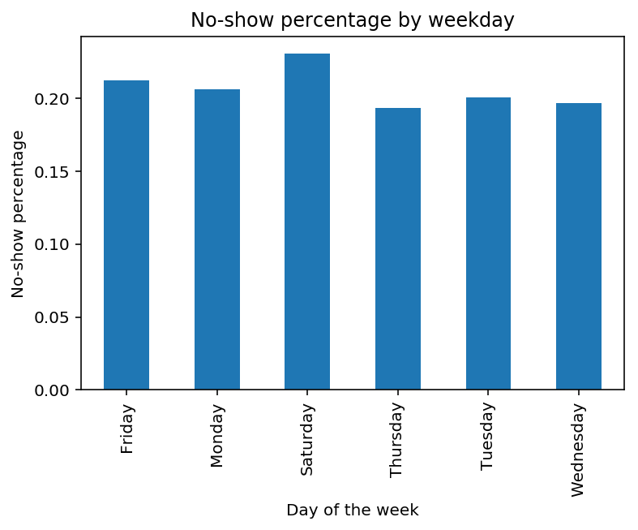

```python
plot_title = 'No-show percentage by weekday'
ax = df_day_of_week['conv_No-show'].plot(kind='bar', title=plot_title)
ax.set_ylabel('No-show percentage')
ax.set_xlabel('Day of the week')
```

From the graph we can indicate that the higher percentage of no show is in Saturday whereas Thursday has the lowest percentage

## Conclusions

The questions were What is the influence of the days between the scheduled date and the appointed date and the influence of Age and Gender on the no-show percentage.

The first limitation was in 'Handicap' column the data wasn't 0 or 1 it was the level of Handicap without any explination of what each number is represent. The second limitation is that there was no explination why some patients recived SMS and some weren't, so we couldn't tell if the patients didn't show up because they didn't recived SMS or they have a habit of discard appintements. For this I did not use these columns.

## Submitting your Project

> Before you submit your project, you need to create a .html or .pdf version of this notebook in the workspace here. To do that, run the code cell below. If it worked correctly, you should get a return code of 0, and you should see the generated .html file in the workspace directory (click on the orange Jupyter icon in the upper left).

> Alternatively, you can download this report as .html via the **File** > **Download as** submenu, and then manually upload it into the workspace directory by clicking on the orange Jupyter icon in the upper left, then using the Upload button.

> Once you've done this, you can submit your project by clicking on the "Submit Project" button in the lower right here. This will create and submit a zip file with this .ipynb doc and the .html or .pdf version you created. Congratulations!

```python
from subprocess import call
call(['python', '-m', 'nbconvert', 'Investigate_a_Dataset.ipynb'])
```

```
0
```

```python
#Recurces:
#https://github.com/tkannab/Udacity-DAND-T1-P3-Investigate-a-Dataset/blob/master/investigate-a-dataset.ipynb
#https://github.com/cbrands/investigate-a-dataset/blob/master/project-2-investigate-a-dataset.ipynb
```